# Análisis de Factores de Pronóstico de Cáncer de Mama

Mario Pascual González

```r
# Vamos a centrar todas las figuras y a dejarlas a un tamaño más cómodo
knitr::opts_chunk$set(fig.align='center', fig.width=6, fig.height=4, out.width='70%')
```

## Preprocesamiento

### Análisis Univariante

Primero debemos cargar los datos en formato `.txt`. Podemos también generar una serie de estadísticas básicas sobre el conjunto y algunas distribuciones básicas con `plot`.

```r
ruta <- "~/Proyectos R/Mineria-de-Datos-con-R/datosm_icb.txt"
datos <- read.table(ruta, header = TRUE, sep = " ",
                    dec = ".", na.strings = "NA",
                    stringsAsFactors = TRUE)
```

Comenzamos con algunos comandos básicos.

```r
head(datos) # Podemos visualizar las primeras lineas del conjunto
```

|  | edad | tam | grado | gang | feno | quim | horm | recid |
| --- | --- | --- | --- | --- | --- | --- | --- | --- |
| 1 | 51 | 2.3 | G1 | 0 | Luminal A | No | Yes | NO |
| 2 | 46 | 3.4 | G3 | 4 | Basal like | Yes | No | SI |
| 3 | 49 | 2.1 | G2 | 1 | HER2 enriched | Yes | Yes | NO |
| 4 | 31 | 1.7 | G2 | 1 | Basal like | Yes | No | NO |
| 5 | 36 | 1.5 | G3 | 0 | Basal like | Yes | No | NO |
| 6 | 59 | 3.8 | G3 | 2 | Luminal B | Yes | Yes | NO |

```r
class(datos) # Podemos obtener el dtype del objeto que pasemos como parámetro
```

```
## [1] "data.frame"
```

```r
str(datos) # Da la descripción de la estructura de datos
```

```
## 'data.frame':    500 obs. of  8 variables:
##  $ edad : int  51 46 49 31 36 59 55 36 63 NA ...
##  $ tam  : num  2.3 3.4 2.1 1.7 1.5 3.8 1.5 4 1.8 1.8 ...
##  $ grado: Factor w/ 3 levels "G1","G2","G3": 1 3 2 2 3 3 1 3 2 3 ...
##  $ gang : int  0 4 1 1 0 2 0 2 10 0 ...
##  $ feno : Factor w/ 6 levels "Basal like","HER2 enriched",..: 4 1 2 1 1 5 5 5 4 1 ...
##  $ quim : Factor w/ 2 levels "No","Yes": 1 2 2 2 2 2 1 2 2 2 ...
##  $ horm : Factor w/ 2 levels "No","Yes": 2 1 2 1 1 2 2 1 2 1 ...
##  $ recid: Factor w/ 2 levels "NO","SI": 1 2 1 1 1 1 1 2 2 2 ...
```

```r
summary(datos) # Esta función nos da el resumen estadístico básicos de los datos
```

```
##       edad            tam         grado         gang                  feno
##  Min.   :25.00   Min.   : 0.200   G1: 76   Min.   : 0.00   Basal like   : 59
##  1st Qu.:45.00   1st Qu.: 1.500   G2:279   1st Qu.: 0.00   HER2 enriched: 30
##  Median :55.00   Median : 2.250   G3:145   Median : 1.00   Luminal-HER2 : 19
##  Mean   :55.69   Mean   : 2.524            Mean   : 2.44   Luminal A    :233
##  3rd Qu.:65.00   3rd Qu.: 3.000            3rd Qu.: 3.00   Luminal B    :116
##  Max.   :88.00   Max.   :12.000            Max.   :34.00   TN no-basal  : 23
##  NA's   :15                                NA's   :50      NA's         : 20
##   quim      horm     recid
##  No :176   No :154   NO:424
##  Yes:324   Yes:346   SI: 76
##
##
##
##
##
```

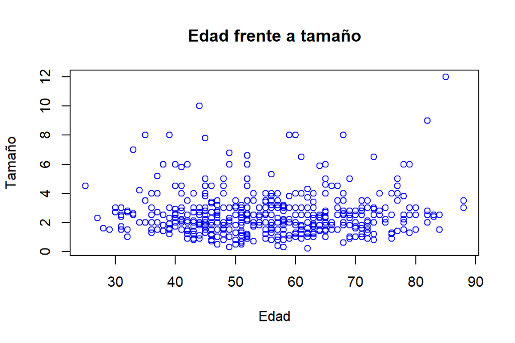

```r
plot(x = datos$edad,
     y = datos$tam,
     xlab = "Edad", ylab = "Tamaño",
     main = "Edad frente a tamaño",
     col = "blue") # Podemos mostrar la distribución discreta de dos variables con plot
```

El tipo de datos que R utiliza para representar las variables categóricas se denomina `factor`. Debido a que la mayoría de datos nos van a llegar en formato string cuando sean categóricos una de las primeras cosas que debemos hacer es pasarlas a factor. Esto podemos hacerlo con la opción `stringsAsFactors = TRUE`.

### Análisis Univariable en R

#### Variables categóricas

Podemos obtener las columnas categóricas de los datos en un vector `c()` utilizando la función `sapply()`, la cual es la equivalente a las listas comprimidas de Python `[x for x in ...]`.

```r
var_categoricas <- colnames(datos)[sapply(datos, function(columna) {
  class(columna) == "factor"
})]
var_categoricas
```

```
## [1] "grado" "feno"  "quim"  "horm"  "recid"
```

Sin embargo, como se puede ver, en Python para poder operar sobre las columnas de un dataframe utilizando una lista comprimida habría que seleccionar `datos.columns`, sin embargo, `sapply` ya accede directamente a la unidad más lógica sobre la que se puede operar -para un `data.frame`, las columnas.

Podemos contar los valores únicos de cada variable categórica:

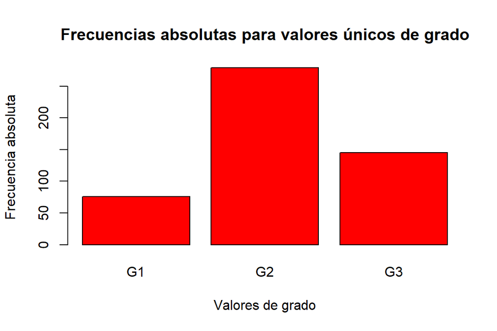

```r
distro_grado <- table(datos$grado)
barplot(height = distro_grado,
        xlab = "Valores de grado", ylab = "Frecuencia absoluta",
        main = "Frecuencias absolutas para valores únicos de grado", col = "red")
```

Una de las principales gráficas que debemos usar para la representación de variables categóricas es `barplot()`. Una gráfica alternativa sería `pieplot()`, pero no es recomendable usarla ya que está en dos dimensiones, teniendo que calcular el área de cada “quesito” para saber el porcentaje de cada valor sobre el total.

#### Variables numéricas

Podemos calcular variables de tendencia central…

```r
media_edad <- mean(datos$edad, na.rm = TRUE)
mediana_edad <- median(datos$edad, na.rm = TRUE)
sd_edad <- sd(datos$edad, na.rm = TRUE)
print(paste("Media edad: ", media_edad,
            " Mediana edad: ", mediana_edad,
            " Desviación estándar: ", sd_edad))
```

```
## [1] "Media edad:  55.6927835051546  Mediana edad:  55  Desviación estándar:  13.2160390240051"
```

```r
# na.rm = TRUE para ignorar los valores faltantes.
```

Algunas representaciones útiles…

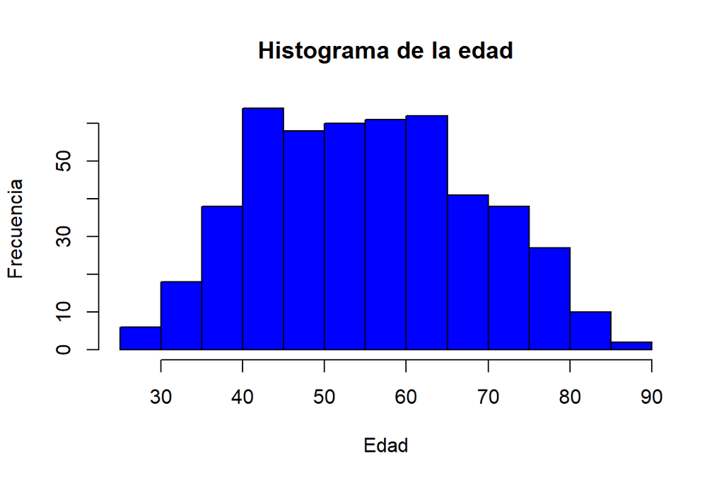

```r
hist(x = datos$edad,
     main = "Histograma de la edad", ylab = "Frecuencia", xlab = "Edad", col = "blue")
```

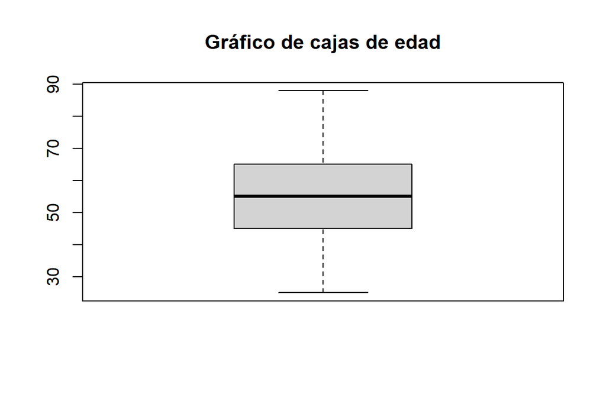

```r
boxplot(datos$edad, main = "Gráfico de cajas de edad") # Muestra el máximo, mínimo, Q1, Q3, y mediana.
```

Podemos también aplicar una estratificación de variables numéricas para dividir nuestros datos en intervalos. La estratificación es útil en problemas clínicos ya que se quieren sacar conclusiones sobre conjuntos de pacientes, por ejemplo, tiene más importancia considerar la información de lso pacientes de 50 a 60 años que la de 55 contra 56.

```r
datos$edad_cat <- cut(datos$edad, breaks = c(0, 40, 60, max(datos$edad, na.rm = TRUE)))
head(datos, 10)
```

|  | edad | tam | grado | gang | feno | quim | horm | recid | edad_cat |
| --- | --- | --- | --- | --- | --- | --- | --- | --- | --- |
| 1 | 51 | 2.3 | G1 | 0 | Luminal A | No | Yes | NO | (40,60] |
| 2 | 46 | 3.4 | G3 | 4 | Basal like | Yes | No | SI | (40,60] |
| 3 | 49 | 2.1 | G2 | 1 | HER2 enriched | Yes | Yes | NO | (40,60] |
| 4 | 31 | 1.7 | G2 | 1 | Basal like | Yes | No | NO | (0,40] |
| 5 | 36 | 1.5 | G3 | 0 | Basal like | Yes | No | NO | (0,40] |
| 6 | 59 | 3.8 | G3 | 2 | Luminal B | Yes | Yes | NO | (40,60] |
| 7 | 55 | 1.5 | G1 | 0 | Luminal B | No | Yes | NO | (40,60] |
| 8 | 36 | 4.0 | G3 | 2 | Luminal B | Yes | No | SI | (0,40] |
| 9 | 63 | 1.8 | G2 | 10 | Luminal A | Yes | Yes | SI | (60,88] |
| 10 | NA | 1.8 | G3 | 0 | Basal like | Yes | No | SI | NA |

### Análisis Bivariante

En el análisis bivariante se estudian las relaciones de pares de variables, tomando como referencia la variable dependiente (objetivo).

Podemos analizar la relación entre dos variables, por ejemplo, grado y recid, haciendo una **tabla de contingencia**.

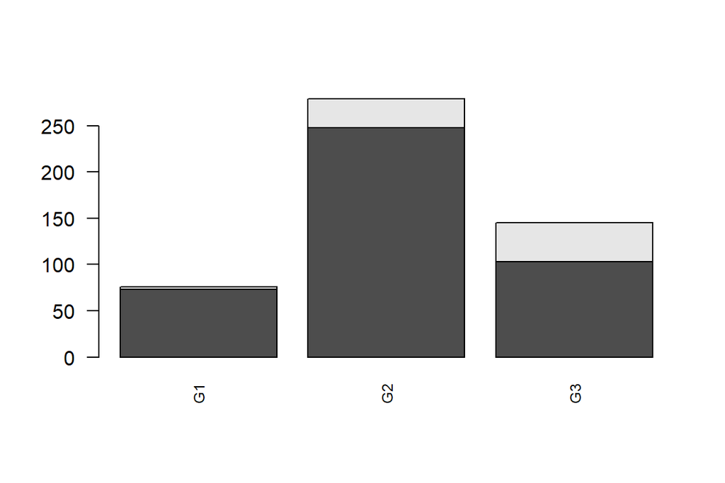

```r
conting_grado <- table(datos$recid, datos$grado)
#Hacemos una representación gráfica

barplot(conting_grado,
        cex.names = .75, las = 2)
```

Podemos además inferir las relaciones cuantitativamente utilizando la *prueba del chi-cuadrado* o el *t-test*.

> El chi cuadrado permite dar una confianza estadística para afirmar que existe una asociación entre dos variables estadísticas. Comprueba si la distirbución teórica esperable es igual que la distribución experimental observable. Esto prueba si existe asociación entre dos variables partiendo de que los datos son aleatorios, comprobando si la diferenica que se observa entre dos variables es resultado de escoger las muestras aleatoriamente o si efectivamente hay un efecto (cuando el grado es mayor, la probabilidad de recidiba es mayor). El chi-cuadrado se utiliza al **comparar dos variables categóricas**.

```r
quim.gr.tab <- xtabs(~ recid + grado, data = datos)
quim.gr.tab # Crea lo mismo que table pero con un tipo específico para aplicar
```

```
##      grado
## recid  G1  G2  G3
##    NO  73 248 103
##    SI   3  31  42
```

```r
            # chi cuadrado

res <- chisq.test(quim.gr.tab)
res
```

```
##
##  Pearson's Chi-squared test
##
## data:  quim.gr.tab
## X-squared = 32.401, df = 2, p-value = 9.208e-08
```

Si el *p-value* es menor que 0.05, entonces podemos **rechazar la hipótesis nula y aceptar la hipótesis alternativa**. Esto no nos dice si hay relación o no, ya que hay que definir la hipótesis nula, en el chi cuadrado la hipótesis nula es que las dos variables son independientes.

```r
var_categoricas <- colnames(datos)[sapply(datos, function(columna) {
  class(columna) == "factor"
})]
var_categoricas <- var_categoricas[!var_categoricas %in% c("recid", "edad_cat")]

rechazar <- var_categoricas[
  sapply(var_categoricas, function(variable) {
    tabla_contingencia <- table(datos[[variable]], datos$recid)
    chi <- chisq.test(tabla_contingencia)
    chi$p.value < 0.05
})]
```

```
## Warning in chisq.test(tabla_contingencia): Chi-squared approximation may be
## incorrect
```

```r
rechazar
```

```
## [1] "grado" "feno"  "quim"  "horm"
```

Cuando hay demasiadas categorías de una de las variables las aproximaciones de los tests estadísticos pueden fallar o no ser fiables, es por esto que R muestra un warning. En este caso se deberían de agrupar categorías para tener menos tipos, esto se debe hacer hablando con el cliente. Cuando alguna de las celdas teine un valor por debajo de cinco entonces sale esta advertencia.

En este caso se debe realizar un test de Fisher. Podemos saber qué variable ha sido la que ha dado el error viendo sobre las variables que hemos aplicado si alguna tiene un valor por debajo de 5.

```r
fallo.chi <- var_categoricas[sapply(var_categoricas, function(var) {
  tabla_contingencia <- table(datos[[var]], datos$recid)
  any(tabla_contingencia < 5)
})]
fallo.chi
```

```
## [1] "grado" "feno"
```

Ahora podemos continuar con análisis bivariante para variables numéricas. Para poder observar la distribución podemos utilizar un boxplot tal que:

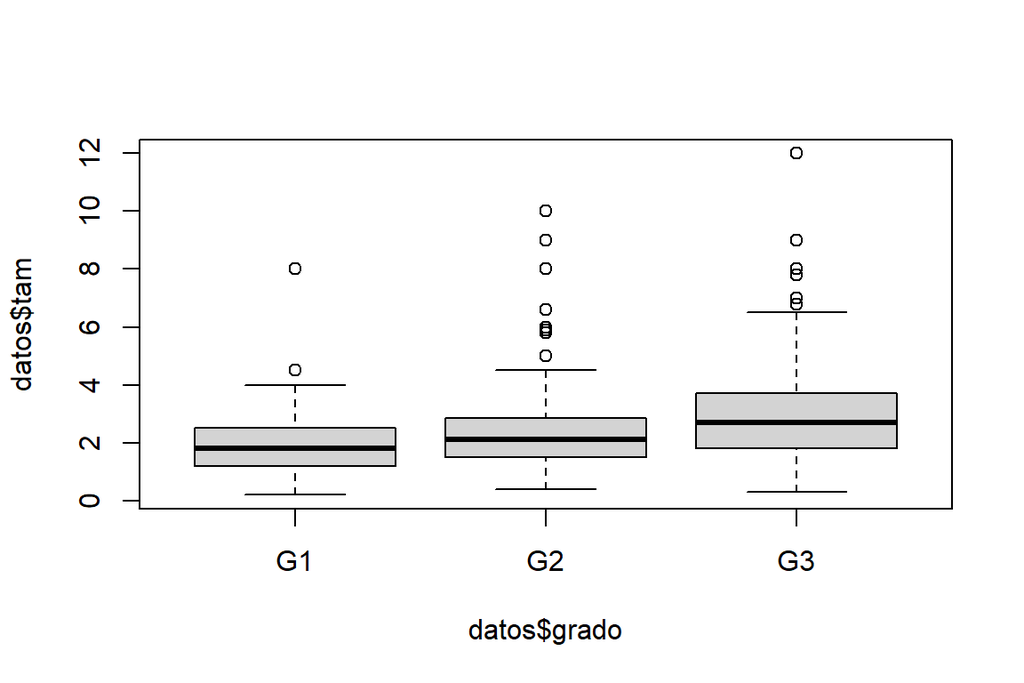

```r
boxplot(datos$tam ~ datos$grado)
```

Para poder ver si dos variables cuantitativas son independientes se utiliza el **t-test**, ya que demuestra si las medias en las distribuciones son iguales o no. La hipótesis nula dice que las medias son iguales.

El intervale de confianza es el rango posible de valores en los que puede estar el valor de la media que se ha calculado. El test estadístico **t-test** calcula este rango de confianza en función de la distribución normal. Cuanto mayor sea el tamaño de la muestra más pequeño será el intervalo de confianza ya que más acertado será el valor de la media con respecto a la media real (poblacional).

```r
t.test(tam ~recid, data = datos)
```

```
##
##  Welch Two Sample t-test
##
## data:  tam by recid
## t = -4.5063, df = 85.236, p-value = 2.085e-05
## alternative hypothesis: true difference in means between group NO and group SI is not equal to 0
## 95 percent confidence interval:
##  -1.6226170 -0.6291457
## sample estimates:
## mean in group NO mean in group SI
##         2.353066         3.478947
```